# Travail pratique 1

Question 1 - Google Trends

Équipe 17

Loïc Artino (536 756 361)

François L'Écuyer (901 346 493)

7 octobre 2020

# Question 1.1 - Expressions à comparer

Dans l'univers du contenu numérique sur Internet, les plateformes Instagram et YouTube occupent une place importante et engendrent un trafic énorme offrant un potentiel de revenu élevé. C'est pourquoi Google (Alphabet) a fait l'acquisition de YouTube pour 1.65 milliards de dollars en nouvelle actions en 2006 et que Facebook a fait l'acquisition d'Instagram pour 1 milliards de dollars en 2012. Alors que YouTube propose du contenu vidéo, Instagram offre du contenu surtout axé sur l'image. Ceci étant dit, nous avons voulu vérifier quel était la plateforme la plus populaire, et si l'avènement d'Instagram avait eu un effet négatif sur la popularité de YouTube. Ce rapport présente donc l'intérêt relatif sur le moteur de recherche sur Google des mots-clés **Instagram** et **Youtube**. Cette analyse comparative a été faite à partir de données importées de l'API Google Trends pour la période du 1 janvier 2010 au 31 août 2020 au Royaume-Uni (GB) et au Canada (CA) où l'intérêt relatif est calculé en divisant chaque point de données par le nombre total de recherches effectuées pour la période et le lieu qu'il représente.

## *Liste partielle des données*

```r
# Importation des données de Google Trends et création du fichier s'il est absent

if (file.exists("gtrendsR.rds") == TRUE) {
  gtrends = readRDS("gtrendsR.rds")
} else {
  keywords = c('YouTube', 'Instagram')
  time_period = '2010-01-01 2020-08-31'
  gtrends = gtrends(keyword = rep(keywords, 2),
                    time = time_period,
                    geo = c('CA', 'CA', 'GB', 'GB'))
  saveRDS(gtrends, file = "gtrendsR.rds")
}

# Sélection et triage des colonnes pour la table interest_over_time

interest_time = gtrends$interest_over_time %>%
  select(date, keyword, geo, hits) %>%
  arrange(date, keyword, geo)

# Remplacement des valeurs < 1 par 0 pour avoir des valeurs discrètes

interest_time$hits = interest_time$hits %>%
  gsub('<1', '0', .) %>%
  as.numeric()
```

Le téléchargement a permis de recevoir **512** observations pour la période et les pays sélectionnés. On peut voir dans le Tableau 1, une partie des données après les avoir importées et nettoyées.

**Tableau 1 - Liste partielle des données**

| date | keyword | geo | hits |
| --- | --- | --- | --- |
| 2010-01-01 | Instagram | CA | 0 |
| 2010-01-01 | Instagram | GB | 0 |
| 2010-01-01 | YouTube | CA | 64 |
| 2010-01-01 | YouTube | GB | 87 |
| 2010-02-01 | Instagram | CA | 0 |
| 2010-02-01 | Instagram | GB | 0 |
| 2010-02-01 | YouTube | CA | 65 |
| 2010-02-01 | YouTube | GB | 94 |
| 2010-03-01 | Instagram | CA | 0 |
| 2010-03-01 | Instagram | GB | 0 |

Note : Instagram a débuté ses opérations à la fin de l'année 2010.

## *Vérification des valeurs manquantes*

```r
# Extraction des valeurs manquantes

missing1 <- interest_time %>%
    group_by(keyword) %>%
    summarize(na_count = sum(is.na(.)))
```

Pour s'assurer de l'intégrité de toutes les valeurs des **512** observations, une vérification a été faite pour s'assurer qu'il ne subsistait pas de valeurs manquantes. Cette opération nous a permis de constater qu'il restait **0** valeur(s) manquante(s) dont on peut voir la répartition par mot-clé au Tableau 2.

**Tableau 2 - Valeurs manquantes pour les mots-clés Instagram et YouTube**

| keyword | na_count |
| --- | --- |
| Instagram | 0 |
| YouTube | 0 |

# Question 1.2 - Visualisation

On peut voir sur la Figure 1, les résultats de l'analyse portant sur l'intérêt relatif des mots-clés **Instagram** et **YouTube** au Canada et au Royaume-Uni.

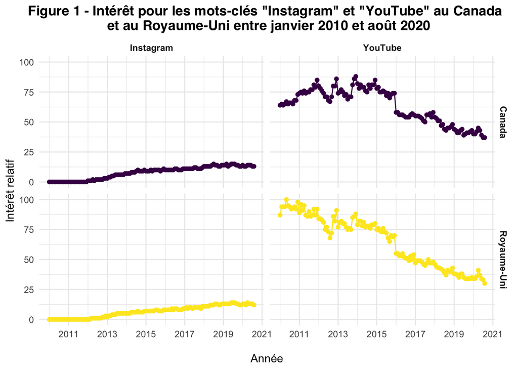

```r
# Création des différentes légendes personnalisées

nom_pays = c("Canada", "Royaume-Uni")
names(nom_pays) = c("CA", "GB")

# Affichage du graphique

ggplot(data = interest_time,
                   aes(x = date, col = geo, y = hits)) +
  geom_line() +
  geom_point() +
  scale_x_datetime(date_breaks = "2 years", date_labels = "%Y") +
  scale_color_viridis(discrete = TRUE) +
  scale_y_continuous(limits = c(0, 100)) +
  labs(x = "\nAnnée",
       y = "Intérêt relatif",
       col = "Pays",
       shape = "Mots-clés") +
  theme_minimal() +
  facet_grid(geo~keyword, labeller = labeller(geo = nom_pays)) +
  ggtitle("Figure 1 - Intérêt pour les mots-clés \"Instagram\" et \"YouTube\" au Canada \n et au Royaume-Uni entre janvier 2010 et août 2020") +
  theme(plot.title = element_text(family = 'Helvetica', face = 'bold', hjust = 0.5),
        legend.position = "none",
        strip.text.x = element_text(face = "bold"),
        strip.text.y = element_text(face = "bold"))
```

À la lumière des résultats, on constate que les internautes ont un intérêt plus grand pour la plateforme YouTube autant au Canada qu'au Royaume-Uni. On remarque cependant qu'Instagram est en hausse depuis son lancement en 2010 alors que YouTube est en perte de vitesse. Il est évidemment risqué de fait un lien entre l'apparition d'Instagram et la perte d'intérêt pour YouTube. La baisse de l'intérêt des internautes pour le mot-clé YouTube peut s'expliquer par de multiples raisons et ne reflète pas nécessairement le succès de YouTube ou la croissance d'Instagram. Par exemple, il est possible que beaucoup d'internautes n'aient plus besoin de rechercher le mot-clé YouTube sur Google après 15 ans d'existence de la plateforme puisque beaucoup la connaissent déjà et disposent d'un raccourci ou de l'application sur leur ordinateur, leur tablette ou leur téléphone intelligent.

# Question 1.3 - Visualisation au choix

Étant donné qu’Instagram est une plateforme en croissance, il nous est apparu intéressant de vérifier comment cela se déclinait dans les provinces canadiennes. L’objectif est de vérifier si le mot-clé Instagram faire l’objet du même intérêt relatif dans chaque province pour la période du 1 janvier 2010 au 31 août 2020.

## *Liste partielle des données par province*

```r
# Création de la table carte CA_map

CA_map = mapcan(boundaries = province, type = standard, territories = TRUE) %>%
  group_by(pr_english) %>%
  mutate(ID = cur_group_id()) %>%
  select(., -hole, -order, -pr_alpha, -pr_french, -pr_sgc_code, -piece)

# Création de la table CA_map2

CA_map2 = gtrends$interest_by_region %>%
  filter(geo == "CA") %>%
  group_by(location) %>%
  mutate(ID = cur_group_id()) %>%
  select(., -gprop) %>%
  filter(keyword == "Instagram") %>%
  inner_join(CA_map, by = "ID")
```

Le téléchargement a permis de recevoir **11430** observations pour la période et les provinces sélectionnées. On peut voir dans le Tableau 3, une partie des données après les avoir importées et nettoyées.

**Tableau 3 - Liste partielle des données**

| location | hits | keyword | geo | ID | long | lat | group | pr_english |
| --- | --- | --- | --- | --- | --- | --- | --- | --- |
| Ontario | 100 | Instagram | CA | 9 | 1056169 | 401665.5 | 35.1 | Ontario |
| Ontario | 100 | Instagram | CA | 9 | 1068027 | 353323.1 | 35.1 | Ontario |
| Ontario | 100 | Instagram | CA | 9 | 1122293 | 134749.2 | 35.1 | Ontario |

## *Vérification des valeurs manquantes*

```r
# Extraction des valeurs manquantes

missing2 <- CA_map2 %>%
  group_by(location) %>%
  summarize(na_count = sum(is.na(.)))
```

Pour s'assurer de l'intégrité des données des **11430** observations de notre table, nous avons vérifié s'il subsistait des valeurs manquantes dans notre table. Cette opération, nous a permis de constater qu'il y avait **0** valeur(s) manquante(s) dans la table dont on peut voir la répartition par province dans le Tableau 4.

**Tableau 4 - Valeurs manquantes pour les provinces canadiennes**

| location | na_count |
| --- | --- |
| Alberta | 0 |
| British Columbia | 0 |
| Manitoba | 0 |
| New Brunswick | 0 |
| Newfoundland and Labrador | 0 |
| Northwest Territories | 0 |
| Nova Scotia | 0 |
| Nunavut | 0 |
| Ontario | 0 |
| Prince Edward Island | 0 |
| Québec | 0 |
| Saskatchewan | 0 |

## *Affichage de la carte*

On peut voir à la Figure 2, que l'intérêt relatif pour le mot-clé Instagram a été représenté sur une carte du Canada en couleur où il est possible de l'observer pour chaque province selon une gradation de couleur.

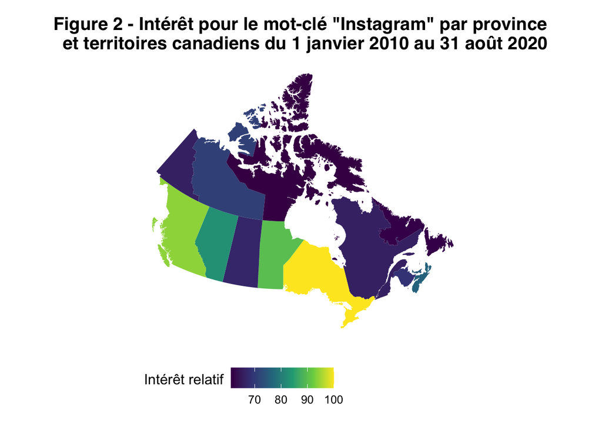

```r
# Affichage de la carte
ggplot(CA_map2, aes(x = long, y = lat, group = group, fill = hits)) +
  geom_polygon() +
  coord_fixed() +
  theme_mapcan() +
  scale_fill_viridis_c(name = "Intérêt relatif\n", na.value = "grey") +
  ggtitle("Figure 2 - Intérêt pour le mot-clé \"Instagram\" par province \n et territoires canadiens du 1 janvier 2010 au 31 août 2020") +
  theme(plot.title = element_text(family = 'Helvetica', face = 'bold', hjust = 0.5))
```

À la lumière des résultats, on constate que les provinces de l'Ontario et de l'ouest (Colombie-Britannique, Alberta et Manitoba) démontrent un intérêt relatif supérieur pour le mot-clé Instagram. Cependant, les territoires du nord et le Québec démontrent un moins grand intérêt. Cela est peut-être dû à la densité de la population plus faible dans les territoires nordiques et du fait francophone au Québec. Instagram est un phénomène assez récent au Québec et les influenceurs francophones qui y opèrent, profitent d'une popularité très inférieure aux influenceurs de langue anglaise.